# Lab 5: Variable selection

Complete problem 3 parts a, b, and c from Ch 7 of *MARR*.

On parts a, b, and c, substitute these instructions – **Identify the optimal model or models based on $R^2_{adj}, C_p$, and $BIC$ from the approach based on …** – for the instructions in *MARR*.

```r
library(tidyverse)
library(leaps)
library(alr4)
```

[output not shown]

```r
##read the file
pgatour <- read.csv("~/Desktop/stat5310/lab5/pgatour2006.csv")
str(pgatour)
```

```
'data.frame':   196 obs. of  12 variables:
 $ Name              : chr  "Aaron Baddeley" "Adam Scott" "Alex Aragon" "Alex Cejka" ...
 $ TigerWoods        : int  0 0 0 0 0 0 0 0 0 0 ...
 $ PrizeMoney        : int  60661 262045 3635 17516 16683 107294 50620 57273 86782 23396 ...
 $ AveDrivingDistance: num  288 301 303 289 288 ...
 $ DrivingAccuracy   : num  60.7 62 51.1 66.4 63.2 ...
 $ GIR               : num  58.3 69.1 59.1 67.7 64 ...
 $ PuttingAverage    : num  1.75 1.77 1.79 1.78 1.76 ...
 $ BirdieConversion  : num  31.4 30.4 29.9 29.3 29.3 ...
 $ SandSaves         : num  54.8 53.6 37.9 45.1 52.4 ...
 $ Scrambling        : num  59.4 57.9 50.8 54.8 57.1 ...
 $ BounceBack        : num  19.3 19.4 16.8 17.1 18.2 ...
 $ PuttsPerRound     : num  28 29.3 29.2 29.5 28.9 ...
```

```r
head(pgatour)
```

|  | Name | TigerWoods | PrizeMoney | AveDrivingDistance | DrivingAccuracy | GIR | PuttingAverage | BirdieConversion | SandSaves | Scrambling | BounceBack | PuttsPerRound |
| --- | --- | --- | --- | --- | --- | --- | --- | --- | --- | --- | --- | --- |
| 1 | Aaron Baddeley | 0 | 60661 | 288.3 | 60.73 | 58.26 | 1.745 | 31.36 | 54.80 | 59.37 | 19.30 | 27.96 |
| 2 | Adam Scott | 0 | 262045 | 301.1 | 62.00 | 69.12 | 1.767 | 30.39 | 53.61 | 57.94 | 19.35 | 29.28 |
| 3 | Alex Aragon | 0 | 3635 | 302.6 | 51.12 | 59.11 | 1.787 | 29.89 | 37.93 | 50.78 | 16.80 | 29.20 |
| 4 | Alex Cejka | 0 | 17516 | 288.8 | 66.40 | 67.70 | 1.777 | 29.33 | 45.13 | 54.82 | 17.05 | 29.46 |
| 5 | Arjun Atwal | 0 | 16683 | 287.7 | 63.24 | 64.04 | 1.761 | 29.32 | 52.44 | 57.07 | 18.21 | 28.93 |
| 6 | Arron Oberholser | 0 | 107294 | 285.0 | 62.53 | 69.27 | 1.775 | 29.20 | 47.20 | 57.67 | 20.00 | 29.56 |

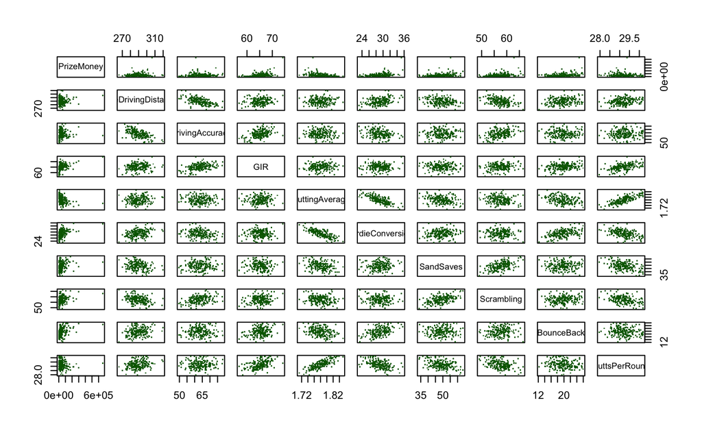

```r
## pairwise scatter plot to examine
pairs(pgatour[,-1:-2], col="darkgreen", pch=".")
```

```r
## multivariate Box-Cox transformation
summary(powerTransform(cbind(PrizeMoney,DrivingAccuracy, GIR, PuttingAverage, BirdieConversion, SandSaves, Scrambling, PuttsPerRound) ~1, data=pgatour))
```

```
bcPower Transformations to Multinormality
                 Est Power Rounded Pwr Wald Lwr Bnd Wald Upr Bnd
PrizeMoney          0.0365           0      -0.0684       0.1414
DrivingAccuracy     0.2764           1      -0.8963       1.4492
GIR                 1.5216           1       0.0892       2.9540
PuttingAverage      1.0089           1      -3.5395       5.5574
BirdieConversion    0.8909           1      -0.1522       1.9340
SandSaves           0.9938           1       0.0552       1.9325
Scrambling          0.6764           1      -0.7417       2.0945
PuttsPerRound      -0.0376           1      -3.2737       3.1986

Likelihood ratio test that transformation parameters are equal to 0
 (all log transformations)
```

|  | LRT | df | pval |
| --- | --- | --- | --- |
| LR test, lambda = (0 0 0 0 0 0 0 0) | 12.85866 | 8 | 0.11681 |

```
Likelihood ratio test that no transformations are needed
```

|  | LRT | df | pval |
| --- | --- | --- | --- |
| LR test, lambda = (1 1 1 1 1 1 1 1) | 338.2418 | 8 | < 2.22e-16 |

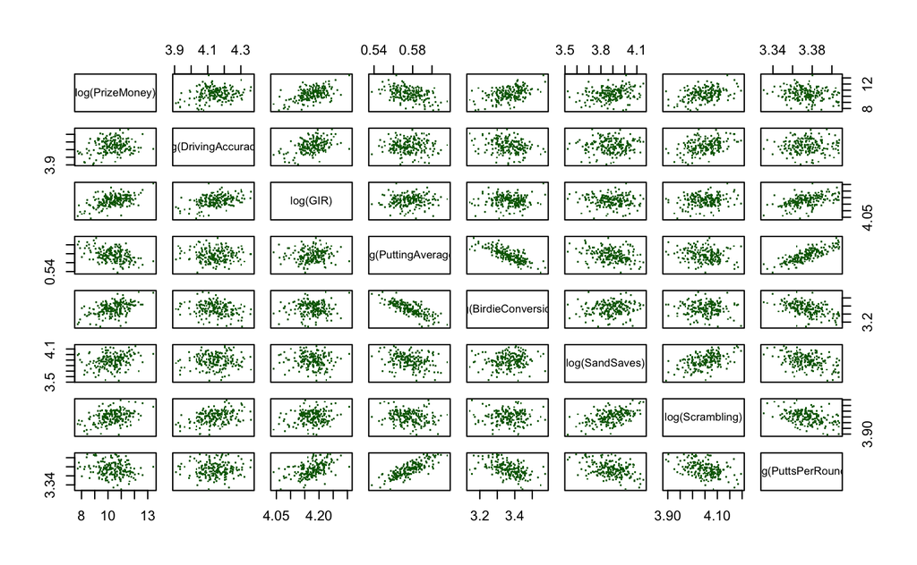

```r
## take log() for every variables to get closer to multivariate normality
pairs(log(PrizeMoney)~ log(DrivingAccuracy) + log(GIR) + log(PuttingAverage) + log(BirdieConversion) + log(SandSaves) + log(Scrambling) + log(PuttsPerRound), data=pgatour, col="darkgreen", pch=".")
```

```r
## transformed data
logpgatour <- pgatour
logpgatour[,3:10] <- log(pgatour[,3:10])
head(logpgatour,3)
```

|  | Name | TigerWoods | PrizeMoney | AveDrivingDistance | DrivingAccuracy | GIR | PuttingAverage | BirdieConversion | SandSaves | Scrambling | BounceBack | PuttsPerRound |
| --- | --- | --- | --- | --- | --- | --- | --- | --- | --- | --- | --- | --- |
| 1 | Aaron Baddeley | 0 | 11.013056 | 5.664002 | 4.106438 | 4.064916 | 0.5567546 | 3.445533 | 4.003690 | 4.083789 | 19.30 | 27.96 |
| 2 | Adam Scott | 0 | 12.476272 | 5.707442 | 4.127134 | 4.235844 | 0.5692832 | 3.414114 | 3.981736 | 4.059408 | 19.35 | 29.28 |
| 3 | Alex Aragon | 0 | 8.198364 | 5.712412 | 3.934176 | 4.079400 | 0.5805382 | 3.397524 | 3.635742 | 3.927503 | 16.80 | 29.20 |

```r
## fit MLR model
logmodel <- lm(PrizeMoney ~ DrivingAccuracy + GIR + PuttingAverage + BirdieConversion + SandSaves + Scrambling + PuttsPerRound, data = logpgatour)
summary(logmodel)
```

```
Call:
lm(formula = PrizeMoney ~ DrivingAccuracy + GIR + PuttingAverage +
    BirdieConversion + SandSaves + Scrambling + PuttsPerRound,
    data = logpgatour)

Residuals:
     Min       1Q   Median       3Q      Max
-1.71327 -0.49537 -0.09754  0.44440  2.17613

Coefficients:
                 Estimate Std. Error t value Pr(>|t|)
(Intercept)      -62.0725     9.6137  -6.457 8.89e-10 ***
DrivingAccuracy   -0.2688     0.7449  -0.361 0.718571
GIR               12.9982     2.8220   4.606 7.55e-06 ***
PuttingAverage    -0.9122    12.1530  -0.075 0.940244
BirdieConversion   4.4530     1.1596   3.840 0.000168 ***
SandSaves          0.7351     0.4735   1.553 0.122216
Scrambling         2.9868     1.8071   1.653 0.100037
PuttsPerRound     -0.3468     0.4683  -0.741 0.459915
---
Signif. codes:  0 ‘***’ 0.001 ‘**’ 0.01 ‘*’ 0.05 ‘.’ 0.1 ‘ ’ 1

Residual standard error: 0.6633 on 188 degrees of freedom
Multiple R-squared:  0.5585,    Adjusted R-squared:  0.542
F-statistic: 33.97 on 7 and 188 DF,  p-value: < 2.2e-16
```

**We can see that there are two variables that are statistically significant - GIR and BirdieConversion. The F-statistic is also highly significant.** **There are three variables that have negative sign.**

```r
cor(logpgatour[,3:12]) %>% round(3)
```

```
                   PrizeMoney AveDrivingDistance DrivingAccuracy    GIR PuttingAverage
PrizeMoney              1.000              0.077           0.193  0.507         -0.430
AveDrivingDistance      0.077              1.000          -0.591  0.166          0.084
DrivingAccuracy         0.193             -0.591           1.000  0.429         -0.031
GIR                     0.507              0.166           0.429  1.000          0.058
PuttingAverage         -0.430              0.084          -0.031  0.058          1.000
BirdieConversion        0.464              0.373          -0.244  0.027         -0.768
SandSaves               0.240             -0.234           0.039 -0.084         -0.265
Scrambling              0.369             -0.381           0.402  0.196         -0.201
BounceBack              0.402              0.239           0.012  0.294         -0.319
PuttsPerRound          -0.183              0.257           0.057  0.479          0.792
                   BirdieConversion SandSaves Scrambling BounceBack PuttsPerRound
PrizeMoney                    0.464     0.240      0.369      0.402        -0.183
AveDrivingDistance            0.373    -0.234     -0.381      0.239         0.257
DrivingAccuracy              -0.244     0.039      0.402      0.012         0.057
GIR                           0.027    -0.084      0.196      0.294         0.479
PuttingAverage               -0.768    -0.265     -0.201     -0.319         0.792
BirdieConversion              1.000     0.128     -0.032      0.481        -0.500
SandSaves                     0.128     1.000      0.493      0.024        -0.421
Scrambling                   -0.032     0.493      1.000      0.091        -0.417
BounceBack                    0.481     0.024      0.091      1.000        -0.135
PuttsPerRound                -0.500    -0.421     -0.417     -0.135         1.000
```